# Case Study on Network Intrusion Detection

# Context:

The dataset to be audited was provided which consists of a wide variety of intrusions simulated in a military network environment It created an environment to acquire raw TCP/IP dump data for a network by simulating a typical US Air Force LAN. The LAN was focused like a real environment and blasted with multiple attacks. A connection is a sequence of TCP packets starting and ending at some time duration between which data flows to and from a source IP address to a target IP address under some well-defined protocol. Also, each connection is labelled as either normal or as an attack with exactly one specific attack type. Each connection record consists of about 100 bytes. For each TCP/IP connection, 41 quantitative and qualitative features are obtained from normal and attack data (3 qualitative and 38 quantitative features) .The class variable has two categories: • Normal • Anomalous

# Dataset:

https://www.kaggle.com/what0919/intrusion-detection

Data basically represents the packet data for a time duration of 2 seconds. 1-9 Columns: basic features of packet (type 1)

10-22 columns: employ the content features (type 2)

23-31 columns: employ the traffic features with 2 seconds of time window (type 4)

32-41 columns: employ the host based features

Feature name Variable type Type Description

Duration C 1 No. of seconds of the connection

Protocol_type D 1 Type of protocol

```
                                     E.g.: TCP,UDP ,ICMP
```

Service D 1 Network service on the destination E.g.: http, telnet

Flag D 1 Normal or error status of the connection

src_bytes C 1 Number of data bytes from source to destination

dst_bytes C 1 Number of data bytes from destination to source

Land D 1 1-connection is from the same host/port: 0-otherwise

Wrong_fragment C 1 No. of ‘wrong’ fragments

Urgent C 1 No of urgent fragments

Hot C 2 The count of access to system directories, creation and execution of programs

Num_failed_logins C 2 No. of failed login attempts

Logged_in D 2 1-successfully logged in 0-otherwise

num_compromised C 2 No. of compromised conditions

Root_shell C 2 1-root shell is obtained;0 otherwise

Su_attempted C 2 1-‘su root’ command attempted;0 otherwise

Num_root C 2 No .of root accesses

num_file_creations C 2 Number of file creation operations

Num_shells C 2 No of shell prompts

Num_access_files C 2 No. of write ,delete and create operations on access control files

Num_outbound_cmds C 2 No. of outbound commands in an ftp session

Is_hot_login D 2 1-the login belongs to the ‘hot’ list 0: otherwise

Count C 3 No. of connections to the same host as the current connection in the past seconds

Srv_count C 3 No of connections to the same host as the current connection in the past 2 seconds

serror_rate C 3 % of connections that have ‘SYN’ errors to the same host

Srv_serror_rate C 3 % of connections that have ‘SYN’ errors to the same service

Rerror_rate C 3 % of connections that have ‘REJ’ errors to the same host

Srv_diff_host_rate C 3 % of connections to different services and to the same host

Dst_host_count C 3 No of connections to the same host to the destination host as the current connection in the past 2 seconds

Dst_host_srv_count C 3 No of connections from the same service to the destination host as the current connection in the past 2 seconds

dst_host_srv_count C 3 No. of connections from the same service to the destination host as the current connection in the past 2 seconds

Dst_host_srv_count C 3 No. of connections from the same service to the destination host as the current connection in the past 2 seconds

Dst_host_same_srv_rate C 3 % of connections from the same service to the destination host

Dst_host_diff_srv_rate C 3 % of connections from the different services to the destination host

Dst_host_same_src_port_rate C 3 % of connections from the port services to the destination host

Dst_host_srv_diff_host_rate C 3 % of connections from the different hosts from the same service to destination host

Dst_host_serror_rate C 3 % of connections that have ‘SYN” errors to same host to the destination host

dst_host_srv_serror_rate C 3 % of connections that have ‘SYN’ errors from the same service to the destination host

Dst_host_rerror_rate C 3 % of connections that have ‘REJ’ errors from the same host to destination host

Dst_host_srv_rerror_rate C 3 % of connections that have ‘REJ’ errors from the same service to the destination host

```python
import pandas as pd
import numpy as np
import matplotlib.pyplot as plt
import seaborn as sns
```

```python
network = pd.read_csv("~/Downloads/Network_Intrusion.csv")
```

```python
network.head()

# Anamoly means that the network has been compromised. It has been Intruded or being made vulnerable.
```

|  | duration | protocol_type | service | flag | src_bytes | dst_bytes | land | wrong_fragment | urgent | hot | ... | dst_host_srv_count | dst_host_same_srv_rate | dst_host_diff_srv_rate | dst_host_same_src_port_rate | dst_host_srv_diff_host_rate | dst_host_serror_rate | dst_host_srv_serror_rate | dst_host_rerror_rate | dst_host_srv_rerror_rate | class |
| --- | --- | --- | --- | --- | --- | --- | --- | --- | --- | --- | --- | --- | --- | --- | --- | --- | --- | --- | --- | --- | --- |
| 0 | 0 | tcp | ftp_data | SF | 491 | 0 | 0 | 0 | 0 | 0 | ... | 25 | 0.17 | 0.03 | 0.17 | 0.00 | 0.00 | 0.00 | 0.05 | 0.00 | normal |
| 1 | 0 | udp | other | SF | 146 | 0 | 0 | 0 | 0 | 0 | ... | 1 | 0.00 | 0.60 | 0.88 | 0.00 | 0.00 | 0.00 | 0.00 | 0.00 | normal |
| 2 | 0 | tcp | private | S0 | 0 | 0 | 0 | 0 | 0 | 0 | ... | 26 | 0.10 | 0.05 | 0.00 | 0.00 | 1.00 | 1.00 | 0.00 | 0.00 | anomaly |
| 3 | 0 | tcp | http | SF | 232 | 8153 | 0 | 0 | 0 | 0 | ... | 255 | 1.00 | 0.00 | 0.03 | 0.04 | 0.03 | 0.01 | 0.00 | 0.01 | normal |
| 4 | 0 | tcp | http | SF | 199 | 420 | 0 | 0 | 0 | 0 | ... | 255 | 1.00 | 0.00 | 0.00 | 0.00 | 0.00 | 0.00 | 0.00 | 0.00 | normal |

5 rows × 42 columns

```python
# shape and info
network.shape
```

```
(25192, 42)
```

```python
network.info()
```

```
<class 'pandas.core.frame.DataFrame'>
RangeIndex: 25192 entries, 0 to 25191
Data columns (total 42 columns):
duration                       25192 non-null int64
protocol_type                  25192 non-null object
service                        25192 non-null object
flag                           25192 non-null object
src_bytes                      25192 non-null int64
dst_bytes                      25192 non-null int64
land                           25192 non-null int64
wrong_fragment                 25192 non-null int64
urgent                         25192 non-null int64
hot                            25192 non-null int64
num_failed_logins              25192 non-null int64
logged_in                      25192 non-null int64
num_compromised                25192 non-null int64
root_shell                     25192 non-null int64
su_attempted                   25192 non-null int64
num_root                       25192 non-null int64
num_file_creations             25192 non-null int64
num_shells                     25192 non-null int64
num_access_files               25192 non-null int64
num_outbound_cmds              25192 non-null int64
is_host_login                  25192 non-null int64
is_guest_login                 25192 non-null int64
count                          25192 non-null int64
srv_count                      25192 non-null int64
serror_rate                    25192 non-null float64
srv_serror_rate                25192 non-null float64
rerror_rate                    25192 non-null float64
srv_rerror_rate                25192 non-null float64
same_srv_rate                  25192 non-null float64
diff_srv_rate                  25192 non-null float64
srv_diff_host_rate             25192 non-null float64
dst_host_count                 25192 non-null int64
dst_host_srv_count             25192 non-null int64
dst_host_same_srv_rate         25192 non-null float64
dst_host_diff_srv_rate         25192 non-null float64
dst_host_same_src_port_rate    25192 non-null float64
dst_host_srv_diff_host_rate    25192 non-null float64
dst_host_serror_rate           25192 non-null float64
dst_host_srv_serror_rate       25192 non-null float64
dst_host_rerror_rate           25192 non-null float64
dst_host_srv_rerror_rate       25192 non-null float64
class                          25192 non-null object
dtypes: float64(15), int64(23), object(4)
memory usage: 8.1+ MB
```

```python
# Missing Values from the dataset
network.isnull().sum()
```

```
duration                       0
protocol_type                  0
service                        0
flag                           0
src_bytes                      0
dst_bytes                      0
land                           0
wrong_fragment                 0
urgent                         0
hot                            0
num_failed_logins              0
logged_in                      0
num_compromised                0
root_shell                     0
su_attempted                   0
num_root                       0
num_file_creations             0
num_shells                     0
num_access_files               0
num_outbound_cmds              0
is_host_login                  0
is_guest_login                 0
count                          0
srv_count                      0
serror_rate                    0
srv_serror_rate                0
rerror_rate                    0
srv_rerror_rate                0
same_srv_rate                  0
diff_srv_rate                  0
srv_diff_host_rate             0
dst_host_count                 0
dst_host_srv_count             0
dst_host_same_srv_rate         0
dst_host_diff_srv_rate         0
dst_host_same_src_port_rate    0
dst_host_srv_diff_host_rate    0
dst_host_serror_rate           0
dst_host_srv_serror_rate       0
dst_host_rerror_rate           0
dst_host_srv_rerror_rate       0
class                          0
dtype: int64
```

```python
network.protocol_type.value_counts()
```

```
tcp     20526
udp      3011
icmp     1655
Name: protocol_type, dtype: int64
```

```python
# Target Variable - Lets find the frequency of Anomalous and Normal
network["class"].value_counts()
```

```
normal     13449
anomaly    11743
Name: class, dtype: int64
```

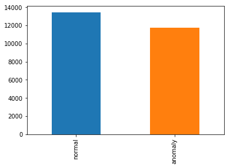

```python
pd.value_counts(network["class"]).plot(kind="bar")
# Barplot of Target Variable
```

```python
# Label Encoding
from sklearn.preprocessing import LabelEncoder
le = LabelEncoder() # initiating the label encoder
```

```python
network["class"] = le.fit_transform(network["class"]) # Normal is rep by 1 and Anomaly - 0
network["protocol_type"] = le.fit_transform(network.protocol_type)
network["service"] = le.fit_transform(network.service)
network["flag"] = le.fit_transform(network.flag)
```

```python
network.head()
```

|  | duration | protocol_type | service | flag | src_bytes | dst_bytes | land | wrong_fragment | urgent | hot | ... | dst_host_srv_count | dst_host_same_srv_rate | dst_host_diff_srv_rate | dst_host_same_src_port_rate | dst_host_srv_diff_host_rate | dst_host_serror_rate | dst_host_srv_serror_rate | dst_host_rerror_rate | dst_host_srv_rerror_rate | class |
| --- | --- | --- | --- | --- | --- | --- | --- | --- | --- | --- | --- | --- | --- | --- | --- | --- | --- | --- | --- | --- | --- |
| 0 | 0 | 1 | 19 | 9 | 491 | 0 | 0 | 0 | 0 | 0 | ... | 25 | 0.17 | 0.03 | 0.17 | 0.00 | 0.00 | 0.00 | 0.05 | 0.00 | 1 |
| 1 | 0 | 2 | 41 | 9 | 146 | 0 | 0 | 0 | 0 | 0 | ... | 1 | 0.00 | 0.60 | 0.88 | 0.00 | 0.00 | 0.00 | 0.00 | 0.00 | 1 |
| 2 | 0 | 1 | 46 | 5 | 0 | 0 | 0 | 0 | 0 | 0 | ... | 26 | 0.10 | 0.05 | 0.00 | 0.00 | 1.00 | 1.00 | 0.00 | 0.00 | 0 |
| 3 | 0 | 1 | 22 | 9 | 232 | 8153 | 0 | 0 | 0 | 0 | ... | 255 | 1.00 | 0.00 | 0.03 | 0.04 | 0.03 | 0.01 | 0.00 | 0.01 | 1 |
| 4 | 0 | 1 | 22 | 9 | 199 | 420 | 0 | 0 | 0 | 0 | ... | 255 | 1.00 | 0.00 | 0.00 | 0.00 | 0.00 | 0.00 | 0.00 | 0.00 | 1 |

5 rows × 42 columns

#### Apply Standard Scaling

The purpose of standard scaling of numerical variables is required if the datapoints have different scale of measurements and hence the ML model will not be able to learn the correct pattern from those datapoints.

This is where we need scaling. It is done by subsracting all the data points with the mean and dividing it by the sd.

This will bring the data into a standard scale where the mean is 0 and sd is 1

```python
from sklearn.preprocessing import StandardScaler
sc = StandardScaler()
```

```python
sc.fit(network)
```

```
StandardScaler(copy=True, with_mean=True, with_std=True)
```

```python
scaled_network = pd.DataFrame(sc.fit_transform(network), columns=network.columns)
```

```python
scaled_network.head()
```

|  | duration | protocol_type | service | flag | src_bytes | dst_bytes | land | wrong_fragment | urgent | hot | ... | dst_host_srv_count | dst_host_same_srv_rate | dst_host_diff_srv_rate | dst_host_same_src_port_rate | dst_host_srv_diff_host_rate | dst_host_serror_rate | dst_host_srv_serror_rate | dst_host_rerror_rate | dst_host_srv_rerror_rate | class |
| --- | --- | --- | --- | --- | --- | --- | --- | --- | --- | --- | --- | --- | --- | --- | --- | --- | --- | --- | --- | --- | --- |
| 0 | -0.113551 | -0.126061 | -0.645384 | 0.753021 | -0.009889 | -0.039310 | -0.00891 | -0.091223 | -0.006301 | -0.091933 | ... | -0.813985 | -0.779157 | -0.280673 | 0.073120 | -0.287993 | -0.641804 | -0.627365 | -0.221668 | -0.374281 | 0.934425 |
| 1 | -0.113551 | 2.215916 | 0.768925 | 0.753021 | -0.010032 | -0.039310 | -0.00891 | -0.091223 | -0.006301 | -0.091933 | ... | -1.030895 | -1.157831 | 2.764403 | 2.375620 | -0.287993 | -0.641804 | -0.627365 | -0.385140 | -0.374281 | 0.934425 |
| 2 | -0.113551 | -0.126061 | 1.090360 | -0.739924 | -0.010093 | -0.039310 | -0.00891 | -0.091223 | -0.006301 | -0.091933 | ... | -0.804947 | -0.935081 | -0.173828 | -0.478183 | -0.287993 | 1.603834 | 1.614454 | -0.385140 | -0.374281 | -1.070177 |
| 3 | -0.113551 | -0.126061 | -0.452524 | 0.753021 | -0.009996 | 0.052473 | -0.00891 | -0.091223 | -0.006301 | -0.091933 | ... | 1.264742 | 1.069663 | -0.440940 | -0.380894 | 0.073759 | -0.574435 | -0.604947 | -0.385140 | -0.342768 | 0.934425 |
| 4 | -0.113551 | -0.126061 | -0.452524 | 0.753021 | -0.010010 | -0.034582 | -0.00891 | -0.091223 | -0.006301 | -0.091933 | ... | 1.264742 | 1.069663 | -0.440940 | -0.478183 | -0.287993 | -0.641804 | -0.627365 | -0.385140 | -0.374281 | 0.934425 |

5 rows × 42 columns

```python
# define the x and y values
x = scaled_network.drop("class", axis = 1)
y = network["class"] # Because this column if scaled, will not work with KNN.
```

```python
# Split the data in train and test
from sklearn.cross_validation import train_test_split
xtrain,xtest,ytrain,ytest = train_test_split(x,y, test_size = 0.30,
                                             random_state = 0)
```

```python
print(xtrain.shape)
print(xtest.shape)
```

```
(17634, 41)
(7558, 41)
```

## Apply KNN Model

```python
from sklearn.neighbors import KNeighborsClassifier # works well with classification probs
from sklearn.metrics import accuracy_score, confusion_matrix
knn = KNeighborsClassifier(n_neighbors= 3) # Default is 05
```

```python
# Apply knn on train and test and make predictions
knn.fit(xtrain, ytrain)
```

```
KNeighborsClassifier(algorithm='auto', leaf_size=30, metric='minkowski',
           metric_params=None, n_jobs=1, n_neighbors=3, p=2,
           weights='uniform')
```

```python
# Predicting the values on xtest
knn_pred = knn.predict(xtest)
```

```python
# evaluate the accuracy
accuracy_score(ytest,knn_pred) # k-1(.20) : 0.9950386981543957, k-5: 0.9926572732685056
# k -5 (.30 data): 0.9917967716327071, k-1(0.30):0.9947075946017465
```

```
0.9940460439269648
```

### Finding the Optimal K Value

1. Take the range of the values 0 to 50
2. Calculate the Error Rate
3. Plot the Error Rate vs Range of k Values (0 to 50)
4. In Plot, the lowest error rate will define the optimal k value for KNN

```python
error_rate = []

for i in range(1,50):
    knn = KNeighborsClassifier(n_neighbors=i)
    knn.fit(xtrain,ytrain)
    pred_i = knn.predict(xtest)
    error_rate.append(np.mean(pred_i != ytest)) # y test is the actual TRUE value
```

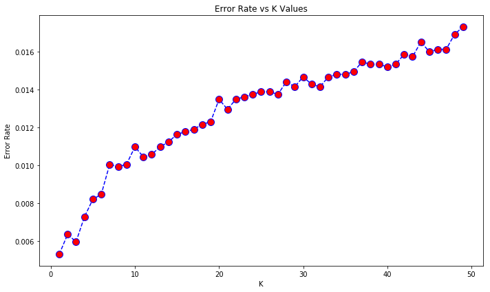

```python
# Plot the Error Model Vs K Values
plt.figure(figsize=[10,6])
plt.plot(range(1,50), error_rate, color = "blue", linestyle = "dashed",
        marker = "o", markerfacecolor = "red", markersize = 10)
plt.title("Error Rate vs K Values")
plt.xlabel("K")
plt.ylabel("Error Rate")
plt.tight_layout()
```

# Error Value vs K Plot

Here in this plot, we see that error is increasing with the K Value and its nearly either 1 or 2 or 3 that appears to be the best possible K Values. Hence, we can take K = 3 and because the errors dipped down at k = 3 and hence we decide to take the K value as 3 to be our optimal value.